# Kid_IGEO_Analysis

Matthew Jordan

2018-10-31

# 1 Preprocessing

Read in the data and edit it suitably.

```r
kid_data <- list.files("data/Kid_IGEO_Results") %>%
  str_c("data/Kid_IGEO_Results/", .) %>%
  map_dfr(
    .x = .,
    .f = read_csv,
    col_types = cols()
  ) %>%
  set_names(
    x = .,
    nm = c("image", "trial", "correct_ans", "condition", "random",
      "given_ans", "response", "reaction_time", "subject_no")
  ) %>%
  mutate(
    spherical = str_sub(condition, 1, 3),
    planar = str_extract(condition, "curve|line"),
    surface = str_extract(condition, "sphere|plane")
  ) %>%
  mutate_at(
    .vars = c("subject_no", "response", "spherical",
      "planar", "surface", "correct_ans", "given_ans"),
    .funs = factor
  ) %>%
  mutate(
    response = factor(response, labels = c("incorrect", "correct"))
    ) %>%
  select(subject_no, trial, image, surface, planar, spherical, response,
    reaction_time, correct_ans, given_ans) %>%
  arrange(surface, desc(planar), desc(spherical))


# Get the info about size, separation, pull, spin
kid_data %<>%
  mutate(image_stripped = str_remove_all(image,
    "gPlane_|Plane_|Sphere_|gSphere_|_.jpg")) %>%
  separate(
    col = image_stripped,
    into = c("size", "separation", "pull", "spin"),
    sep = "_",
    remove = TRUE
  ) %>%
  mutate(pull = str_replace(pull, fixed("(Neg)"), "-")) %>%
  mutate_at(
    .vars = c("size", "separation", "pull", "spin"),
    .funs = as.numeric
  )

# Load into the data the specifics about the height,
# line length, rotation angle, etc.
kid_data %<>%
  mutate(
    pull = replace_na(pull, 0),
    point_sep_rad = point_sep_rad(separation),
    rotation_angle = case_when(
      planar == "line" & spherical == "arc" ~ 0,
      TRUE ~ pmap(
        .l = list(size, separation, pull, spin),
        .f = rot_angle
      ) %>% unlist()
    ),
    height = by_case(
      col_1 = planar, col_2 = spherical,
      gl = 0,
      gc = pmap(.l = list(size, separation, pull), .f = height_gc) %>% unlist(),
      al = map2(.x = size, .y = pull, .f = height_al) %>% unlist(),
      ac = pmap(.l = list(size, separation, pull, spin), .f = height_ac) %>% unlist()
    ),
    height = abs(height)/radius(size),
    line_length = by_case(
      col_1 = planar, col_2 = spherical,
      gl = map2(.x = size, .y = separation, .f = length_gl) %>% unlist(),
      gc = map2(.x = size, .y = separation, .f = length_gc) %>% unlist(),
      al = pmap(.l = list(size, separation, pull), .f = length_al) %>% unlist(),
      ac = pmap(.l = list(size, separation, pull), .f = length_ac) %>% unlist()
    ),
    curvature = by_case(
      col_1 = planar, col_2 = spherical,
      gl = 0,
      gc = pmap(.l = list(size, separation, pull), .f = curvature_gc) %>% unlist(),
      al = 0,
      ac = pmap(.l = list(size, separation, pull, spin), .f = curvature_ac) %>% unlist()
    )
  ) %>%
  filter(!is.na(response)) %>%
  select(everything(), response, reaction_time)

write_csv(x = kid_data, path = "data/kid_data.csv")
```

# 2 Descriptives

Get the overall correct vs. incorrect proportion.

```r
num_trials <- kid_data %>% nrow()

# Get the overall correct proportion
all_trials <- kid_data %>%
  group_by(response) %>%
  summarise(
    count = n(),
    percentage = str_c(100*round(count/(num_trials), 3), "%")
  )

# Summarize
all_trials %>%
  kable(.)
```

| response | count | percentage |
| --- | --- | --- |
| incorrect | 888 | 32.4% |
| correct | 1856 | 67.6% |

We see that 67.5% of all responses are correct. Let’s break this down by category.

```r
# Break results down by category
kid_descriptives <- kid_data %>%
  mutate(response = as.numeric(response) - 1) %>%
  group_by(surface, spherical, planar) %>%
  summarise(percentage_correct = mean(response)) %>%
  mutate(condition = sprintf("%s_%s_%s", surface, spherical, planar)) %>%
  select(everything()) %>%
  ungroup() %>%
  arrange(surface, desc(planar), desc(spherical))

# Summarize
kid_descriptives %>%
  select(condition, percentage_correct) %>%
  kable(.)
```

| condition | percentage_correct |
| --- | --- |
| plane_geo_line | 0.9970845 |
| plane_arc_line | 0.9941691 |
| plane_geo_curve | 0.5685131 |
| plane_arc_curve | 0.6938776 |
| sphere_geo_line | 0.9708455 |
| sphere_arc_line | 0.0291545 |
| sphere_geo_curve | 0.6676385 |
| sphere_arc_curve | 0.4897959 |

Let’s plot these descriptives. Notice right away the performance on the arc line condition for spheres: only 3% of responses were correct.

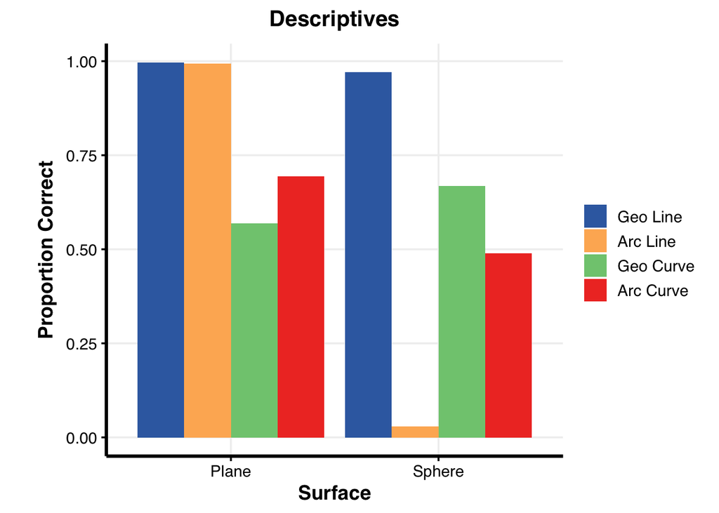

```r
my_labs <- function(){
  labs(
    x = "Surface",
    y = "Proportion Correct",
    fill = " ",
    title = "Descriptives"
  )
}

kid_descriptives %>%
  mutate(
    condition = sprintf("%s %s", str_to_title(spherical), str_to_title(planar)),
    condition = factor(condition, levels = unique(condition))
    ) %>%
  ggplot(data = .,
    aes(x = str_to_title(surface), y = percentage_correct, fill = condition)) +
  geom_bar(position = position_dodge(width = NULL), stat = "identity") +
  my_labs() + IGEO_theme() + IGEO_fill()
```

# 3 Analysis

## 3.1 Above Chance

```r
# All trials together
model_above_chance <- kid_data %>%
  glmer(
    data = .,
    response ~ (1 | subject_no),
    family = binomial(link = "logit")
    )

# Take a look
model_above_chance %>%
  tidy() %>%
  filter(term == "(Intercept)") %>%
  mutate(term = "Intercept") %>%
  mutate(
    p_value = "0.0000",
    p_value_clean = clean_p_val(p.value),
    p_value_star = stars.pval(p.value)
  ) %>%
  rename(
    "std_error" = std.error,
    "log_odds" = estimate
    ) %>%
  select(-p.value, -group) %>%
  kable(.)
```

| term | log_odds | std_error | statistic | p_value | p_value_clean | p_value_star |
| --- | --- | --- | --- | --- | --- | --- |
| Intercept | 0.7388609 | 0.0432387 | 17.08797 | 0.0000 | p < 0.001 | *** |

Overall, performance is above chance.
$$\frac{1}{1+\exp{(-0.739)}} = 67.7\%.$$
We now break up by category.

```r
# Split up by category
model_above_chance_split <- kid_data %>%
  group_by(surface, spherical, planar) %>%
  do(
    above_chance = glmer(
      data = .,
      response ~ (1 | subject_no),
      family = binomial(link = "logit")
      )
    )

# Look at results
model_above_chance_split %>%
  tidy(above_chance, conf.int = TRUE) %>%
  ungroup() %>%
  filter(term == "(Intercept)") %>%
  mutate(
    p_value = round(p.value, 4),
    p_value_clean = clean_p_val(p.value),
    p_value_star = gtools::stars.pval(p_value),
    condition = sprintf("%s_%s_%s", surface, spherical, planar)
  ) %>%
  arrange(surface, desc(planar), desc(spherical)) %>%
  mutate(probability = 1/(1 + exp(-estimate))) %>%
  rename(
    "std_error" = std.error,
    "log_odds" = estimate,
    "conf_lower" = conf.low,
    "conf_upper" = conf.high
    ) %>%
  select(condition, everything(), -term, -surface, -planar,
    -spherical, -group, -p.value) %>%
  kable(.)
```

| condition | log_odds | std_error | statistic | conf_lower | conf_upper | p_value | p_value_clean | p_value_star | probability |
| --- | --- | --- | --- | --- | --- | --- | --- | --- | --- |
| plane_geo_line | 5.8348107 | 1.0014603 | 5.8263023 | 3.8719845 | 7.7976369 | 0.0000 | p < 0.001 | *** | 0.9970845 |
| plane_arc_line | 5.1387352 | 0.7091667 | 7.2461602 | 3.7487941 | 6.5286763 | 0.0000 | p < 0.001 | *** | 0.9941691 |
| plane_geo_curve | 0.3190949 | 0.1688166 | 1.8901871 | -0.0117795 | 0.6499692 | 0.0587 | 0.059 | . | 0.5791037 |
| plane_arc_curve | 1.0717732 | 0.2309761 | 4.6401908 | 0.6190683 | 1.5244780 | 0.0000 | p < 0.001 | *** | 0.7449340 |
| sphere_geo_line | 8.9074012 | 1.9991004 | 4.4557047 | 4.9892363 | 12.8255661 | 0.0000 | p < 0.001 | *** | 0.9998646 |
| sphere_arc_line | -8.9074033 | 2.0003422 | -4.4529397 | -12.8280021 | -4.9868046 | 0.0000 | p < 0.001 | *** | 0.0001354 |
| sphere_geo_curve | 0.9076626 | 0.2229337 | 4.0714461 | 0.4707205 | 1.3446046 | 0.0000 | p < 0.001 | *** | 0.7125216 |
| sphere_arc_curve | -0.0429639 | 0.1310459 | -0.3278539 | -0.2998091 | 0.2138813 | 0.7430 | 0.743 |  | 0.4892607 |

Performance was significantly different from chance except in two cases: geodesic curves on planes and arc curves on spheres. Interestingly, the arc curves on planes were significant. Unusual since on the plane, curves are curves, regardless of geo vs. arc.

## 3.2 Model 1

### 3.2.1 Run The Model

```r
model_1 <- glmer(
  data = kid_data,
  formula = response ~ surface * planar * spherical + (1 + surface + planar | subject_no),
  family = binomial(link = "logit")
  )

# Show the results
clean_IGEO_model(
  model = model_1,
  col_names = c("Intercept", "Surface", "Planar", "Spherical",
    "Surface x Planar", "Surface x Spherical", "Planar x Spherical",
    "Surface x Planar x Spherical")
)
```

| term | log_odds | std_error | statistic | conf_lower | conf_upper | p_value | p_value_clean | p_value_star |
| --- | --- | --- | --- | --- | --- | --- | --- | --- |
| Intercept | 1.0465899 | 0.2183896 | 4.792307 | 0.6185542 | 1.4746256 | 0.0000 | p < 0.001 | *** |
| Surface | -1.0879955 | 0.2474506 | -4.396820 | -1.5729897 | -0.6030014 | 0.0000 | p < 0.001 | *** |
| Planar | 4.8747021 | 0.7881724 | 6.184817 | 3.3299125 | 6.4194917 | 0.0000 | p < 0.001 | *** |
| Spherical | -0.6885082 | 0.1800847 | -3.823247 | -1.0414677 | -0.3355487 | 0.0001 | p < 0.001 | *** |
| Surface x Planar | -8.3399264 | 0.8604290 | -9.692754 | -10.0263361 | -6.6535166 | 0.0000 | p < 0.001 | *** |
| Surface x Spherical | 1.4276715 | 0.2392732 | 5.966701 | 0.9587047 | 1.8966383 | 0.0000 | p < 0.001 | *** |
| Planar x Spherical | 1.3994198 | 1.2500480 | 1.119493 | -1.0506293 | 3.8494689 | 0.2629 | 0.263 |  |
| Surface x Planar x Spherical | 4.8760481 | 1.3396015 | 3.639924 | 2.2504774 | 7.5016187 | 0.0003 | p < 0.001 | *** |

All significant except for `Planar x Spherical`. These two terms only interact in the presence of the `Surface` term.

### 3.2.2 Marginal Means

```r
# Estimated Marginal Means
model_1_predicted <- emmeans(
  object = model_1,
  specs = ~ surface * planar * spherical ,
  type = "response"
  )

model_1_predicted_clean <- clean_IGEO_emmeans(model_1_predicted)

model_1_predicted_clean %>%
  kable()
```

| surface | planar | spherical | probability | std_error | conf_lower | conf_upper |
| --- | --- | --- | --- | --- | --- | --- |
| plane | line | geo | 0.9986845 | 0.0014102 | 0.9959205 | 1.0014484 |
| plane | line | arc | 0.9973254 | 0.0021378 | 0.9931354 | 1.0015155 |
| plane | curve | geo | 0.5885760 | 0.0511318 | 0.4883576 | 0.6887944 |
| plane | curve | arc | 0.7401195 | 0.0420056 | 0.6577885 | 0.8224505 |
| sphere | line | geo | 0.9709146 | 0.0090696 | 0.9531381 | 0.9886910 |
| sphere | line | arc | 0.0291242 | 0.0090879 | 0.0113119 | 0.0469365 |
| sphere | curve | geo | 0.6676904 | 0.0254712 | 0.6177668 | 0.7176140 |
| sphere | curve | arc | 0.4896501 | 0.0270300 | 0.4366713 | 0.5426288 |

Here is a plot of these model predictions.

**Model 1 plot code**

```r
my_labs <- function(){
  labs(
    x = "Surface",
    y = "Predicted Proportion Correct",
    fill = " ",
    title = "Model 1 Predictions"
  )
}

model_1_plot <- model_1_predicted_clean %>%
   mutate(
      condition = sprintf("%s %s", str_to_title(spherical), str_to_title(planar)),
      condition = factor(condition, levels = unique(condition))
    ) %>%
  ggplot(data = ., aes(x = str_to_title(surface), y = probability, fill = condition)) +
  geom_bar(position = position_dodge(width = NULL), stat = "identity") +
  geom_errorbar(aes(ymin = conf_lower, ymax = conf_upper),
    position = position_dodge(0.9), width = 0.2, size = 0.4) +
  my_labs() + IGEO_theme() + IGEO_fill()
```

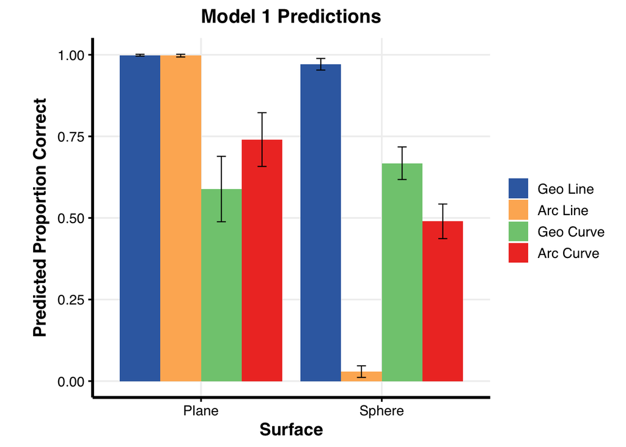

```r
model_1_plot
```

This plot looks a great deal like the graph of the descriptives for each, but it was generated by an explanatory model which we can use to better understand these data.

### 3.2.3 Contrasts

```r
# Compute contrasts
contrast(
  object = model_1_predicted,
  by = c("surface"),
  method = "pairwise",
  adjust = "holm"
  ) %>%
  clean_IGEO_contrasts()
```

| surface | contrast | odds_ratio | std_error | p_value | p_value_clean | p_value_star |
| --- | --- | --- | --- | --- | --- | --- |
| plane | curve,arc / line,arc | 0.0076374 | 0.0060196 | 0.0000 | p < 0.001 | *** |
| plane | curve,arc / curve,geo | 1.9907435 | 0.3585024 | 0.0003 | p < 0.001 | *** |
| plane | curve,arc / line,geo | 0.0037514 | 0.0039894 | 0.0000 | p < 0.001 | *** |
| plane | line,arc / curve,geo | 260.6582895 | 205.8967095 | 0.0000 | p < 0.001 | *** |
| plane | line,arc / line,geo | 0.4911962 | 0.6075544 | 0.5655 | 0.565 |  |
| plane | curve,geo / line,geo | 0.0018844 | 0.0020066 | 0.0000 | p < 0.001 | *** |
| sphere | curve,arc / line,arc | 31.9836308 | 10.8493781 | 0.0000 | p < 0.001 | *** |
| sphere | curve,arc / curve,geo | 0.4775133 | 0.0752300 | 0.0000 | p < 0.001 | *** |
| sphere | curve,arc / line,geo | 0.0287417 | 0.0097431 | 0.0000 | p < 0.001 | *** |
| sphere | line,arc / curve,geo | 0.0149299 | 0.0050968 | 0.0000 | p < 0.001 | *** |
| sphere | line,arc / line,geo | 0.0008986 | 0.0004084 | 0.0000 | p < 0.001 | *** |
| sphere | curve,geo / line,geo | 0.0601903 | 0.0205350 | 0.0000 | p < 0.001 | *** |

Note that kids perform significantly better for arc curves on planes than they do for geo curves on planes. This is unexpected, since on planes, the arc vs. geo distinction is meaningless, and all of these stimuli simply appear as curves.

```r
arc_curve_data <- kid_data %>%
  filter(planar == "curve", spherical == "arc") %>%
  select(curvature) %>%
  arrange(curvature) %>%
  unique() %>%
  pull()

geo_curve_data <- kid_data %>%
  filter(planar == "curve", spherical == "geo") %>%
  select(curvature) %>%
  arrange(curvature) %>%
  unique() %>%
  pull()

tibble(
  arc_curve = arc_curve_data,
  geo_curve = geo_curve_data
  ) %>%
  kable(.)
```

| arc_curve | geo_curve |
| --- | --- |
| 0.0233917 | 0.0123426 |
| 0.0825483 | 0.0225285 |
| 0.0856949 | 0.0327952 |
| 0.0960396 | 0.0470876 |
| 0.0967457 | 0.0619559 |
| 0.0970798 | 0.0660149 |
| 0.1681470 | 0.1562871 |

```r
kid_data %>%
  filter(planar == "curve") %>%
  group_by(spherical) %>%
  summarize(
    mean_curvature = round(100*mean(curvature), 3),
    max_curvature = round(100*max(curvature), 3),
    min_curvature = round(100*min(curvature), 3),
    sd_curvature = round(100*sd(curvature), 3)
  ) %>%
  kable(.)
```

| spherical | mean_curvature | max_curvature | min_curvature | sd_curvature |
| --- | --- | --- | --- | --- |
| arc | 9.281 | 16.815 | 2.339 | 3.912 |
| geo | 5.700 | 15.629 | 1.234 | 4.448 |

## 3.3 Model 1b

```r
kid_data %>%
  group_by(subject_no) %>%
  summarise(
    percentage_yes = mean(given_ans == "y")
  ) %>%
  arrange(desc(percentage_yes)) %>%
  head() %>%
  kable()
```

| subject_no | percentage_yes |
| --- | --- |
| 47 | 1.0000000 |
| 23 | 0.8928571 |
| 25 | 0.8928571 |
| 59 | 0.8928571 |
| 37 | 0.8750000 |
| 3 | 0.8571429 |

```r
model_1b <- kid_data %>%
  filter(surface == "sphere") %>%
  glmer(
    data = .,
    formula = given_ans ~ planar * spherical + (1 + planar | subject_no),
    family = binomial(link = "logit")
    )

# Show the results
clean_IGEO_model(
  model = model_1b,
  col_names =  c("Intercept", "Planar", "Spherical", "Planar x Spherical")
  )
```

| term | log_odds | std_error | statistic | conf_lower | conf_upper | p_value | p_value_clean | p_value_star |
| --- | --- | --- | --- | --- | --- | --- | --- | --- |
| Intercept | 0.0377111 | 0.1833674 | 0.2056587 | -0.3216824 | 0.3971046 | 0.8371 | 0.837 |  |
| Planar | 9.1944749 | 1.9125121 | 4.8075381 | 5.4460200 | 12.9429298 | 0.0000 | p < 0.001 | *** |
| Spherical | 0.7909920 | 0.1748456 | 4.5239456 | 0.4483009 | 1.1336831 | 0.0000 | p < 0.001 | *** |
| Planar x Spherical | -0.5417379 | 0.7291312 | -0.7429910 | -1.9708088 | 0.8873329 | 0.4575 | 0.457 |  |

### 3.3.1 Marginal Means

```r
# Estimated Marginal Means
model_1b_predicted <- emmeans(
    object = model_1b,
    specs = ~ planar * spherical ,
    type = "response"
  )

model_1b_predicted_clean <- model_1b_predicted %>%
  tidy() %>%
  select(-df) %>%
  rename(
    "std_error" = std.error,
    "probability" = prob
    ) %>%
  mutate(
    conf_lower = probability - 1.96*std_error,
    conf_upper = probability + 1.96*std_error
  ) %>%
  arrange(desc(planar), desc(spherical)) %>%
  mutate(surface = "sphere") %>%
  select(surface, everything(), -asymp.LCL, -asymp.UCL)

model_1b_predicted_clean %>%
  kable()
```

| surface | planar | spherical | probability | std_error | conf_lower | conf_upper |
| --- | --- | --- | --- | --- | --- | --- |
| sphere | line | geo | 0.9999238 | 0.0001478 | 0.9996341 | 1.0002134 |
| sphere | line | arc | 0.9999022 | 0.0001871 | 0.9995355 | 1.0002689 |
| sphere | curve | geo | 0.6960806 | 0.0400856 | 0.6175129 | 0.7746484 |
| sphere | curve | arc | 0.5094267 | 0.0458256 | 0.4196086 | 0.5992448 |

Finally, we plot this model’s predictions.

**Model 1b Plot Code**

```r
my_labs <- function(){
  labs(
    x = "Condition",
    y = "Predicted Proportion of\n \"Yes\" Responses",
    fill = " ",
    title = "Model 1b Predictions"
  )
}


model_1b_graph <- model_1b_predicted_clean %>%
  mutate(
    condition = sprintf("%s %s", str_to_title(spherical), str_to_title(planar)),
    condition = factor(condition, levels = unique(condition))
    ) %>%
  ggplot(data = .,
    aes(x = condition, y = probability, fill = condition)) +
  geom_bar(position = position_dodge(width = NULL), stat = "identity") +
  geom_errorbar(aes(ymin = conf_lower, ymax = conf_upper),
    position = position_dodge(0.9), width = 0.2, size = 0.4) +
  my_labs() + IGEO_theme() + IGEO_fill() +
  guides(fill = FALSE)
```

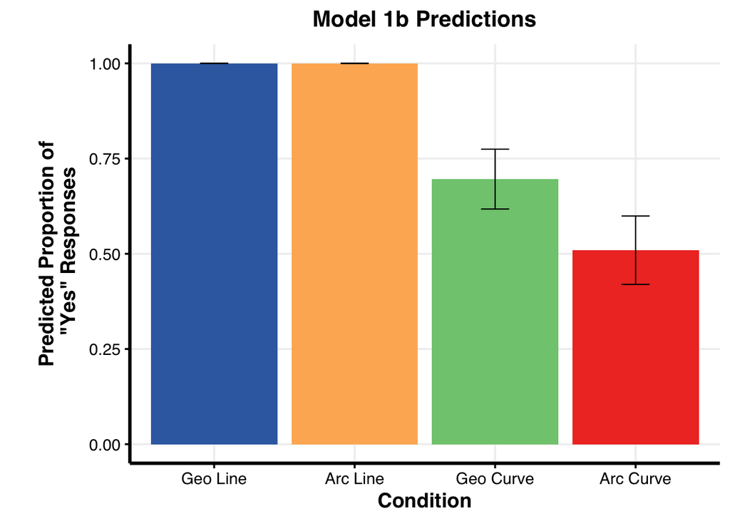

```r
model_1b_graph
```

```r
# Compute contrasts
contrast(
  object = model_1b_predicted,
  method = "pairwise",
  by = c("planar"),
  adjust = "holm"
  ) %>%
  tidy() %>%
  mutate(
    p_value = round(p.value, 4),
    p_value_clean = clean_p_val(p.value),
    p_value_star = stars.pval(p.value)
    ) %>%
  rename(
    "odds_ratio" = odds.ratio,
    "std_error" = std.error
    ) %>%
  select(planar, everything(), -p.value, -z.ratio, -df) %>%
  kable()
```

| planar | contrast | odds_ratio | std_error | p_value | p_value_clean | p_value_star |
| --- | --- | --- | --- | --- | --- | --- |
| curve | arc / geo | 0.4533948 | 0.0792741 | 0.0000 | p < 0.001 | *** |
| line | arc / geo | 0.7793819 | 0.5516923 | 0.7247 | 0.725 |  |

### 3.3.2 Exploratory Analysis

Analyzing just curves.

```r
curves_yes <- kid_data %>%
  filter(planar == "curve") %>%
  glm(
    data = .,
    formula = given_ans ~ surface * spherical,
    family = binomial(link = "logit")
    )

# Show the results
curves_yes %>%
  tidy(conf.int = TRUE) %>%
  mutate(
    p_value = round(p.value, 4),
    p_value_clean = clean_p_val(p.value),
    p_value_star = stars.pval(p.value)
  ) %>%
  select(-p.value) %>%
  mutate(
    term =c("Intercept", "Surface", "Spherical", "Surface x Spherical")
  ) %>%
  rename(
    "conf_lower" = conf.low,
    "conf_upper" = conf.high,
    "std_error" = std.error,
    "log_odds" = estimate
  ) %>%
  kable(.)
```

| term | log_odds | std_error | statistic | conf_lower | conf_upper | p_value | p_value_clean | p_value_star |
| --- | --- | --- | --- | --- | --- | --- | --- | --- |
| Intercept | -0.8183103 | 0.1171558 | -6.9848049 | -1.0516145 | -0.5918403 | 0.0000 | p < 0.001 | *** |
| Surface | 0.8591323 | 0.1593491 | 5.3915093 | 0.5485463 | 1.1735527 | 0.0000 | p < 0.001 | *** |
| Spherical | 0.5425230 | 0.1600326 | 3.3900778 | 0.2300103 | 0.8577289 | 0.0007 | p < 0.001 | *** |
| Surface x Spherical | 0.1141785 | 0.2245347 | 0.5085116 | -0.3260254 | 0.5544175 | 0.6111 | 0.611 |  |

Get the emmeans for this `surface x spherical` model.

```r
# Estimated Marginal Means
curves_yes_predicted <- emmeans(
    object = curves_yes,
    specs = ~ surface * spherical ,
    type = "response"
  )

curves_yes_predicted_clean <- curves_yes_predicted %>%
  tidy() %>%
  select(-df) %>%
  rename(
    "std_error" = std.error,
    "probability" = prob
    ) %>%
  mutate(
    conf_lower = probability - 1.96*std_error,
    conf_upper = probability + 1.96*std_error
  ) %>%
  arrange(surface, desc(spherical)) %>%
  select(surface, everything(), -asymp.LCL, -asymp.UCL)

curves_yes_predicted_clean %>%
  kable(.)
```

| surface | spherical | probability | std_error | conf_lower | conf_upper |
| --- | --- | --- | --- | --- | --- |
| plane | geo | 0.4314869 | 0.0267428 | 0.3790710 | 0.4839028 |
| plane | arc | 0.3061224 | 0.0248852 | 0.2573474 | 0.3548975 |
| sphere | geo | 0.6676385 | 0.0254348 | 0.6177862 | 0.7174908 |
| sphere | arc | 0.5102041 | 0.0269918 | 0.4573001 | 0.5631081 |

```r
contrast(
  object = curves_yes_predicted,
  method = "pairwise",
  adjust = "holm"
  ) %>%
  tidy() %>%
  mutate(
    p_value = round(p.value, 4),
    p_value_clean = clean_p_val(p.value),
    p_value_star = stars.pval(p.value)
    ) %>%
  rename(
    "odds_ratio" = odds.ratio,
    "std_error" = std.error
    ) %>%
  select(everything(), -p.value, -z.ratio, -df) %>%
  kable(.)
```

| contrast | odds_ratio | std_error | p_value | p_value_clean | p_value_star |
| --- | --- | --- | --- | --- | --- |
| plane,arc / sphere,arc | 0.4235294 | 0.0674890 | 0.0000 | p < 0.001 | *** |
| plane,arc / plane,geo | 0.5812798 | 0.0930237 | 0.0014 | p < 0.01 | ** |
| plane,arc / sphere,geo | 0.2196250 | 0.0359972 | 0.0000 | p < 0.001 | *** |
| sphere,arc / plane,geo | 1.3724662 | 0.2106261 | 0.0391 | p < 0.05 | * |
| sphere,arc / sphere,geo | 0.5185590 | 0.0816716 | 0.0001 | p < 0.001 | *** |
| plane,geo / sphere,geo | 0.3778300 | 0.0597685 | 0.0000 | p < 0.001 | *** |

Look at the effect of curvature on the planar arc curves and geo curves.

```r
model_2_curvature <- kid_data %>%
  filter(surface == "plane", planar == "curve") %>%
  glmer(
    data = .,
    formula = response ~ line_length + spherical*curvature + (1 | subject_no),
    family = binomial(link = "logit")
    )

model_2_curvature %>%
  tidy(conf.int = TRUE) %>%
  filter(group == "fixed") %>%
  mutate(
    p_value = round(p.value, 4),
    p_value_clean = clean_p_val(p.value),
    p_value_star = stars.pval(p.value)
  ) %>%
  select(-p.value, -group) %>%
  mutate(
    term =c("Intercept", "Line Length", "Spherical", "Curvature", "Spherical x Curvature")
  ) %>%
  rename(
    "conf_lower" = conf.low,
    "conf_upper" = conf.high,
    "std_error" = std.error,
    "log_odds" = estimate
  ) %>%
  kable(.)
```

| term | log_odds | std_error | statistic | conf_lower | conf_upper | p_value | p_value_clean | p_value_star |
| --- | --- | --- | --- | --- | --- | --- | --- | --- |
| Intercept | -4.3278341 | 0.8237074 | -5.2540918 | -5.9422709 | -2.7133974 | 0.0000 | p < 0.001 | *** |
| Line Length | 0.6785328 | 0.1340164 | 5.0630593 | 0.4158656 | 0.9412001 | 0.0000 | p < 0.001 | *** |
| Spherical | 0.1258361 | 0.7121088 | 0.1767091 | -1.2698714 | 1.5215437 | 0.8597 | 0.86 |  |
| Curvature | 46.8804459 | 6.5136942 | 7.1972132 | 34.1138398 | 59.6470521 | 0.0000 | p < 0.001 | *** |
| Spherical x Curvature | 16.6042795 | 11.9796962 | 1.3860351 | -6.8754936 | 40.0840526 | 0.1657 | 0.166 |  |

Huge effect of curvature!